# Risk Factor Analysis

## Outcome Variable

**Outcome Variable:** ever_co

## Predictor Variables

**Intervention Variable:** vagbrth

**Adjustment Set:**

- arm
- sex
- W_mage
- meducyrs
- feducyrs
- hhwealth_quart
- W_mhtcm
- single
- brthmon
- W_parity
- delta_W_mage
- delta_meducyrs
- delta_feducyrs
- delta_hhwealth_quart
- delta_W_mhtcm
- delta_single
- delta_brthmon
- delta_W_parity

## Stratifying Variables

The analysis was stratified on these variable(s):

- agecat
- studyid
- country

## Data Summary

| agecat | studyid | country | vagbrth | ever_co | n_cell | n |
| --- | --- | --- | --- | --- | --- | --- |
| 0-24 months | ki1000108-CMC-V-BCS-2002 | INDIA | 0 | 0 | 21 | 373 |
| 0-24 months | ki1000108-CMC-V-BCS-2002 | INDIA | 0 | 1 | 4 | 373 |
| 0-24 months | ki1000108-CMC-V-BCS-2002 | INDIA | 1 | 0 | 266 | 373 |
| 0-24 months | ki1000108-CMC-V-BCS-2002 | INDIA | 1 | 1 | 82 | 373 |
| 0-24 months | ki1000108-IRC | INDIA | 0 | 0 | 60 | 410 |
| 0-24 months | ki1000108-IRC | INDIA | 0 | 1 | 10 | 410 |
| 0-24 months | ki1000108-IRC | INDIA | 1 | 0 | 274 | 410 |
| 0-24 months | ki1000108-IRC | INDIA | 1 | 1 | 66 | 410 |
| 0-24 months | ki1017093b-PROVIDE | BANGLADESH | 0 | 0 | 144 | 700 |
| 0-24 months | ki1017093b-PROVIDE | BANGLADESH | 0 | 1 | 16 | 700 |
| 0-24 months | ki1017093b-PROVIDE | BANGLADESH | 1 | 0 | 466 | 700 |
| 0-24 months | ki1017093b-PROVIDE | BANGLADESH | 1 | 1 | 74 | 700 |
| 0-24 months | ki1017093c-NIH-Crypto | BANGLADESH | 0 | 0 | 189 | 500 |
| 0-24 months | ki1017093c-NIH-Crypto | BANGLADESH | 0 | 1 | 15 | 500 |
| 0-24 months | ki1017093c-NIH-Crypto | BANGLADESH | 1 | 0 | 259 | 500 |
| 0-24 months | ki1017093c-NIH-Crypto | BANGLADESH | 1 | 1 | 37 | 500 |
| 0-24 months | ki1066203-TanzaniaChild2 | TANZANIA, UNITED REPUBLIC OF | 0 | 0 | 203 | 2367 |
| 0-24 months | ki1066203-TanzaniaChild2 | TANZANIA, UNITED REPUBLIC OF | 0 | 1 | 9 | 2367 |
| 0-24 months | ki1066203-TanzaniaChild2 | TANZANIA, UNITED REPUBLIC OF | 1 | 0 | 2046 | 2367 |
| 0-24 months | ki1066203-TanzaniaChild2 | TANZANIA, UNITED REPUBLIC OF | 1 | 1 | 109 | 2367 |
| 0-24 months | ki1119695-PROBIT | BELARUS | 0 | 0 | 1948 | 16897 |
| 0-24 months | ki1119695-PROBIT | BELARUS | 0 | 1 | 3 | 16897 |
| 0-24 months | ki1119695-PROBIT | BELARUS | 1 | 0 | 14922 | 16897 |
| 0-24 months | ki1119695-PROBIT | BELARUS | 1 | 1 | 24 | 16897 |
| 0-24 months | ki1126311-ZVITAMBO | ZIMBABWE | 0 | 0 | 1130 | 13820 |
| 0-24 months | ki1126311-ZVITAMBO | ZIMBABWE | 0 | 1 | 40 | 13820 |
| 0-24 months | ki1126311-ZVITAMBO | ZIMBABWE | 1 | 0 | 12115 | 13820 |
| 0-24 months | ki1126311-ZVITAMBO | ZIMBABWE | 1 | 1 | 535 | 13820 |
| 0-24 months | kiGH5241-JiVitA-3 | BANGLADESH | 0 | 0 | 1404 | 26801 |
| 0-24 months | kiGH5241-JiVitA-3 | BANGLADESH | 0 | 1 | 109 | 26801 |

[output cut: 78 more lines]

The following strata were considered:

- agecat: 0-24 months, studyid: ki1000108-CMC-V-BCS-2002, country: INDIA
- agecat: 0-24 months, studyid: ki1000108-IRC, country: INDIA
- agecat: 0-24 months, studyid: ki1017093b-PROVIDE, country: BANGLADESH
- agecat: 0-24 months, studyid: ki1017093c-NIH-Crypto, country: BANGLADESH
- agecat: 0-24 months, studyid: ki1066203-TanzaniaChild2, country: TANZANIA, UNITED REPUBLIC OF
- agecat: 0-24 months, studyid: ki1119695-PROBIT, country: BELARUS
- agecat: 0-24 months, studyid: ki1126311-ZVITAMBO, country: ZIMBABWE
- agecat: 0-24 months, studyid: kiGH5241-JiVitA-3, country: BANGLADESH
- agecat: 0-24 months, studyid: kiGH5241-JiVitA-4, country: BANGLADESH
- agecat: 0-6 months, studyid: ki1000108-CMC-V-BCS-2002, country: INDIA
- agecat: 0-6 months, studyid: ki1000108-IRC, country: INDIA
- agecat: 0-6 months, studyid: ki1017093b-PROVIDE, country: BANGLADESH
- agecat: 0-6 months, studyid: ki1017093c-NIH-Crypto, country: BANGLADESH
- agecat: 0-6 months, studyid: ki1066203-TanzaniaChild2, country: TANZANIA, UNITED REPUBLIC OF
- agecat: 0-6 months, studyid: ki1119695-PROBIT, country: BELARUS
- agecat: 0-6 months, studyid: ki1126311-ZVITAMBO, country: ZIMBABWE
- agecat: 0-6 months, studyid: kiGH5241-JiVitA-3, country: BANGLADESH
- agecat: 0-6 months, studyid: kiGH5241-JiVitA-4, country: BANGLADESH
- agecat: 6-24 months, studyid: ki1000108-CMC-V-BCS-2002, country: INDIA
- agecat: 6-24 months, studyid: ki1000108-IRC, country: INDIA
- agecat: 6-24 months, studyid: ki1017093b-PROVIDE, country: BANGLADESH
- agecat: 6-24 months, studyid: ki1017093c-NIH-Crypto, country: BANGLADESH
- agecat: 6-24 months, studyid: ki1066203-TanzaniaChild2, country: TANZANIA, UNITED REPUBLIC OF
- agecat: 6-24 months, studyid: ki1119695-PROBIT, country: BELARUS
- agecat: 6-24 months, studyid: ki1126311-ZVITAMBO, country: ZIMBABWE
- agecat: 6-24 months, studyid: kiGH5241-JiVitA-3, country: BANGLADESH
- agecat: 6-24 months, studyid: kiGH5241-JiVitA-4, country: BANGLADESH

### Dropped Strata

Some strata were dropped due to rare outcomes:

- agecat: 0-24 months, studyid: ki1000108-CMC-V-BCS-2002, country: INDIA
- agecat: 0-24 months, studyid: ki1119695-PROBIT, country: BELARUS
- agecat: 0-6 months, studyid: ki1000108-CMC-V-BCS-2002, country: INDIA
- agecat: 0-6 months, studyid: ki1017093c-NIH-Crypto, country: BANGLADESH
- agecat: 0-6 months, studyid: ki1066203-TanzaniaChild2, country: TANZANIA, UNITED REPUBLIC OF
- agecat: 0-6 months, studyid: ki1119695-PROBIT, country: BELARUS
- agecat: 6-24 months, studyid: ki1000108-CMC-V-BCS-2002, country: INDIA
- agecat: 6-24 months, studyid: ki1119695-PROBIT, country: BELARUS

## Methods Detail

We’re interested in the causal parameters $E[Y_a]$ for all values of $a \in \mathcal{A}$. These parameters represent the mean outcome if, possibly contrary to fact, we intervened to set all units to have $A=a$. Under the randomization and positivity assumptions, these are identified by the statistical parameters $\psi_a=E_W[E_{Y|A,W}(Y|A=a,W)]$. In addition, we’re interested in the mean of $Y$, $E[Y]$ under no intervention (the observed mean). We will estimate these parameters by using SuperLearner to fit the relevant likelihood factors – $E_{Y|A,W}(Y|A=a,W)$ and $p(A=a|W)$, and then updating our likelihood fit using a joint TMLE.

For unadjusted analyses ($W=\{\}$), initial likelihoods were estimated using Lrnr_glm to estimate the simple $E(Y|A)$ and Lrnr_mean to estimate $p(A)$. For adjusted analyses, a small library containing Lrnr_glmnet, Lrnr_xgboost, and Lrnr_mean was used.

Having estimated these parameters, we will then use the delta method to estimate relative risks and attributable risks relative to a prespecified baseline level of $A$.

# Results Detail

## Results Plots

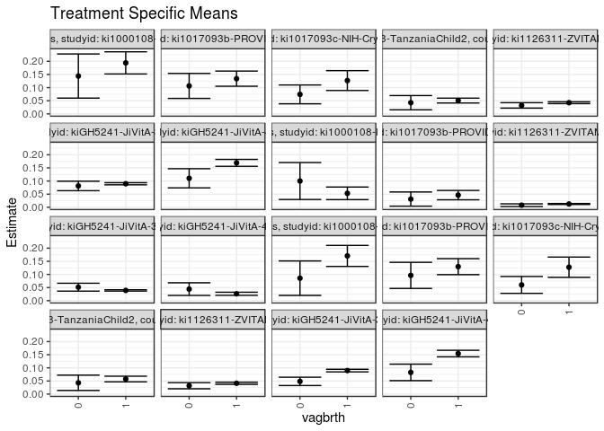

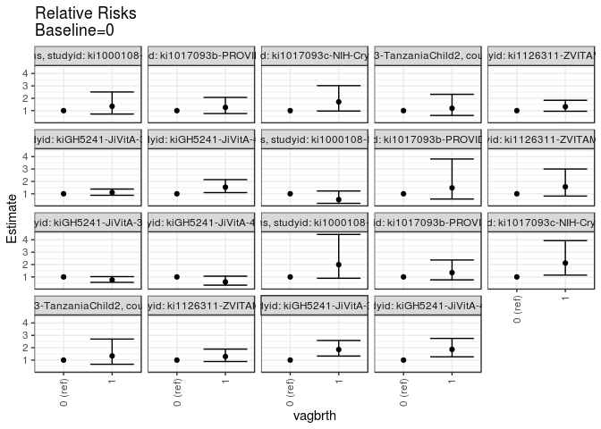

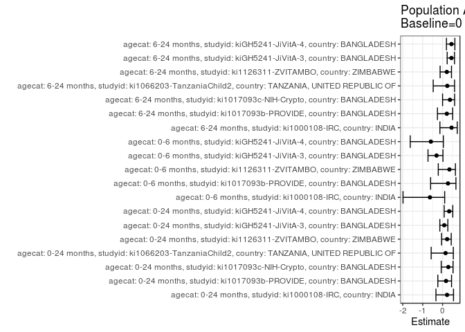

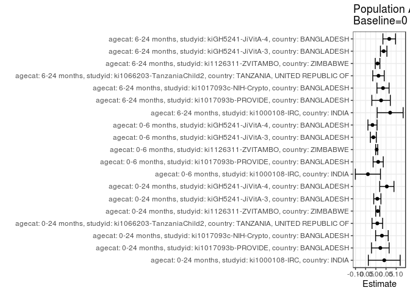

## Results Table

### Parameter: TSM

| agecat | studyid | country | intervention_level | baseline_level | estimate | ci_lower | ci_upper |
| --- | --- | --- | --- | --- | --- | --- | --- |
| 0-24 months | ki1000108-IRC | INDIA | 0 | NA | 0.1439631 | 0.0598904 | 0.2280358 |
| 0-24 months | ki1000108-IRC | INDIA | 1 | NA | 0.1940989 | 0.1519510 | 0.2362468 |
| 0-24 months | ki1017093b-PROVIDE | BANGLADESH | 0 | NA | 0.1063989 | 0.0587952 | 0.1540027 |
| 0-24 months | ki1017093b-PROVIDE | BANGLADESH | 1 | NA | 0.1340289 | 0.1052256 | 0.1628322 |
| 0-24 months | ki1017093c-NIH-Crypto | BANGLADESH | 0 | NA | 0.0741435 | 0.0382686 | 0.1100183 |
| 0-24 months | ki1017093c-NIH-Crypto | BANGLADESH | 1 | NA | 0.1267621 | 0.0889336 | 0.1645906 |
| 0-24 months | ki1066203-TanzaniaChild2 | TANZANIA, UNITED REPUBLIC OF | 0 | NA | 0.0424528 | 0.0153069 | 0.0695988 |
| 0-24 months | ki1066203-TanzaniaChild2 | TANZANIA, UNITED REPUBLIC OF | 1 | NA | 0.0505800 | 0.0413259 | 0.0598342 |
| 0-24 months | ki1126311-ZVITAMBO | ZIMBABWE | 0 | NA | 0.0321451 | 0.0218656 | 0.0424246 |
| 0-24 months | ki1126311-ZVITAMBO | ZIMBABWE | 1 | NA | 0.0424398 | 0.0389211 | 0.0459585 |
| 0-24 months | kiGH5241-JiVitA-3 | BANGLADESH | 0 | NA | 0.0812384 | 0.0632148 | 0.0992621 |
| 0-24 months | kiGH5241-JiVitA-3 | BANGLADESH | 1 | NA | 0.0895258 | 0.0855040 | 0.0935475 |
| 0-24 months | kiGH5241-JiVitA-4 | BANGLADESH | 0 | NA | 0.1103359 | 0.0738507 | 0.1468211 |
| 0-24 months | kiGH5241-JiVitA-4 | BANGLADESH | 1 | NA | 0.1691273 | 0.1560121 | 0.1822426 |
| 0-6 months | ki1000108-IRC | INDIA | 0 | NA | 0.1000000 | 0.0296358 | 0.1703642 |
| 0-6 months | ki1000108-IRC | INDIA | 1 | NA | 0.0530973 | 0.0291989 | 0.0769957 |
| 0-6 months | ki1017093b-PROVIDE | BANGLADESH | 0 | NA | 0.0312500 | 0.0042708 | 0.0582292 |
| 0-6 months | ki1017093b-PROVIDE | BANGLADESH | 1 | NA | 0.0462963 | 0.0285609 | 0.0640317 |
| 0-6 months | ki1126311-ZVITAMBO | ZIMBABWE | 0 | NA | 0.0079659 | 0.0029263 | 0.0130056 |
| 0-6 months | ki1126311-ZVITAMBO | ZIMBABWE | 1 | NA | 0.0124617 | 0.0105181 | 0.0144053 |
| 0-6 months | kiGH5241-JiVitA-3 | BANGLADESH | 0 | NA | 0.0514028 | 0.0363083 | 0.0664974 |
| 0-6 months | kiGH5241-JiVitA-3 | BANGLADESH | 1 | NA | 0.0391114 | 0.0365737 | 0.0416491 |
| 0-6 months | kiGH5241-JiVitA-4 | BANGLADESH | 0 | NA | 0.0440765 | 0.0199396 | 0.0682135 |
| 0-6 months | kiGH5241-JiVitA-4 | BANGLADESH | 1 | NA | 0.0262822 | 0.0203415 | 0.0322229 |
| 6-24 months | ki1000108-IRC | INDIA | 0 | NA | 0.0857143 | 0.0200549 | 0.1513737 |
| 6-24 months | ki1000108-IRC | INDIA | 1 | NA | 0.1705882 | 0.1305570 | 0.2106194 |
| 6-24 months | ki1017093b-PROVIDE | BANGLADESH | 0 | NA | 0.0963720 | 0.0466482 | 0.1460959 |
| 6-24 months | ki1017093b-PROVIDE | BANGLADESH | 1 | NA | 0.1296354 | 0.0992140 | 0.1600567 |
| 6-24 months | ki1017093c-NIH-Crypto | BANGLADESH | 0 | NA | 0.0600382 | 0.0278936 | 0.0921828 |
| 6-24 months | ki1017093c-NIH-Crypto | BANGLADESH | 1 | NA | 0.1274686 | 0.0889025 | 0.1660347 |
| 6-24 months | ki1066203-TanzaniaChild2 | TANZANIA, UNITED REPUBLIC OF | 0 | NA | 0.0430108 | 0.0138471 | 0.0721744 |
| 6-24 months | ki1066203-TanzaniaChild2 | TANZANIA, UNITED REPUBLIC OF | 1 | NA | 0.0574903 | 0.0467609 | 0.0682198 |
| 6-24 months | ki1126311-ZVITAMBO | ZIMBABWE | 0 | NA | 0.0319527 | 0.0202446 | 0.0436607 |
| 6-24 months | ki1126311-ZVITAMBO | ZIMBABWE | 1 | NA | 0.0412994 | 0.0373339 | 0.0452648 |
| 6-24 months | kiGH5241-JiVitA-3 | BANGLADESH | 0 | NA | 0.0484726 | 0.0326135 | 0.0643317 |
| 6-24 months | kiGH5241-JiVitA-3 | BANGLADESH | 1 | NA | 0.0896308 | 0.0846930 | 0.0945687 |
| 6-24 months | kiGH5241-JiVitA-4 | BANGLADESH | 0 | NA | 0.0827117 | 0.0512497 | 0.1141737 |
| 6-24 months | kiGH5241-JiVitA-4 | BANGLADESH | 1 | NA | 0.1544096 | 0.1419549 | 0.1668643 |

### Parameter: E(Y)

| agecat | studyid | country | intervention_level | baseline_level | estimate | ci_lower | ci_upper |
| --- | --- | --- | --- | --- | --- | --- | --- |
| 0-24 months | ki1000108-IRC | INDIA | NA | NA | 0.1853659 | 0.1477057 | 0.2230261 |
| 0-24 months | ki1017093b-PROVIDE | BANGLADESH | NA | NA | 0.1285714 | 0.1037574 | 0.1533855 |
| 0-24 months | ki1017093c-NIH-Crypto | BANGLADESH | NA | NA | 0.1040000 | 0.0772164 | 0.1307836 |
| 0-24 months | ki1066203-TanzaniaChild2 | TANZANIA, UNITED REPUBLIC OF | NA | NA | 0.0498521 | 0.0410826 | 0.0586217 |
| 0-24 months | ki1126311-ZVITAMBO | ZIMBABWE | NA | NA | 0.0416064 | 0.0382770 | 0.0449357 |
| 0-24 months | kiGH5241-JiVitA-3 | BANGLADESH | NA | NA | 0.0886534 | 0.0847769 | 0.0925300 |
| 0-24 months | kiGH5241-JiVitA-4 | BANGLADESH | NA | NA | 0.1643805 | 0.1517702 | 0.1769909 |
| 0-6 months | ki1000108-IRC | INDIA | NA | NA | 0.0611247 | 0.0378797 | 0.0843697 |
| 0-6 months | ki1017093b-PROVIDE | BANGLADESH | NA | NA | 0.0428571 | 0.0278427 | 0.0578716 |
| 0-6 months | ki1126311-ZVITAMBO | ZIMBABWE | NA | NA | 0.0120938 | 0.0102652 | 0.0139225 |
| 0-6 months | kiGH5241-JiVitA-3 | BANGLADESH | NA | NA | 0.0393807 | 0.0369019 | 0.0418595 |
| 0-6 months | kiGH5241-JiVitA-4 | BANGLADESH | NA | NA | 0.0277157 | 0.0217808 | 0.0336506 |
| 6-24 months | ki1000108-IRC | INDIA | NA | NA | 0.1560976 | 0.1209228 | 0.1912723 |
| 6-24 months | ki1017093b-PROVIDE | BANGLADESH | NA | NA | 0.1221498 | 0.0962275 | 0.1480722 |
| 6-24 months | ki1017093c-NIH-Crypto | BANGLADESH | NA | NA | 0.0953390 | 0.0688164 | 0.1218616 |
| 6-24 months | ki1066203-TanzaniaChild2 | TANZANIA, UNITED REPUBLIC OF | NA | NA | 0.0561404 | 0.0460367 | 0.0662440 |
| 6-24 months | ki1126311-ZVITAMBO | ZIMBABWE | NA | NA | 0.0404564 | 0.0367062 | 0.0442067 |
| 6-24 months | kiGH5241-JiVitA-3 | BANGLADESH | NA | NA | 0.0870071 | 0.0823429 | 0.0916713 |
| 6-24 months | kiGH5241-JiVitA-4 | BANGLADESH | NA | NA | 0.1485588 | 0.1367632 | 0.1603543 |

### Parameter: RR

| agecat | studyid | country | intervention_level | baseline_level | estimate | ci_lower | ci_upper |
| --- | --- | --- | --- | --- | --- | --- | --- |
| 0-24 months | ki1000108-IRC | INDIA | 0 | 0 | 1.0000000 | 1.0000000 | 1.000000 |
| 0-24 months | ki1000108-IRC | INDIA | 1 | 0 | 1.3482546 | 0.7245204 | 2.508957 |
| 0-24 months | ki1017093b-PROVIDE | BANGLADESH | 0 | 0 | 1.0000000 | 1.0000000 | 1.000000 |
| 0-24 months | ki1017093b-PROVIDE | BANGLADESH | 1 | 0 | 1.2596826 | 0.7668135 | 2.069343 |
| 0-24 months | ki1017093c-NIH-Crypto | BANGLADESH | 0 | 0 | 1.0000000 | 1.0000000 | 1.000000 |
| 0-24 months | ki1017093c-NIH-Crypto | BANGLADESH | 1 | 0 | 1.7096864 | 0.9681061 | 3.019326 |
| 0-24 months | ki1066203-TanzaniaChild2 | TANZANIA, UNITED REPUBLIC OF | 0 | 0 | 1.0000000 | 1.0000000 | 1.000000 |
| 0-24 months | ki1066203-TanzaniaChild2 | TANZANIA, UNITED REPUBLIC OF | 1 | 0 | 1.1914410 | 0.6126664 | 2.316973 |
| 0-24 months | ki1126311-ZVITAMBO | ZIMBABWE | 0 | 0 | 1.0000000 | 1.0000000 | 1.000000 |
| 0-24 months | ki1126311-ZVITAMBO | ZIMBABWE | 1 | 0 | 1.3202562 | 0.9488621 | 1.837018 |
| 0-24 months | kiGH5241-JiVitA-3 | BANGLADESH | 0 | 0 | 1.0000000 | 1.0000000 | 1.000000 |
| 0-24 months | kiGH5241-JiVitA-3 | BANGLADESH | 1 | 0 | 1.1020125 | 0.8790394 | 1.381544 |
| 0-24 months | kiGH5241-JiVitA-4 | BANGLADESH | 0 | 0 | 1.0000000 | 1.0000000 | 1.000000 |
| 0-24 months | kiGH5241-JiVitA-4 | BANGLADESH | 1 | 0 | 1.5328400 | 1.0960446 | 2.143707 |
| 0-6 months | ki1000108-IRC | INDIA | 0 | 0 | 1.0000000 | 1.0000000 | 1.000000 |
| 0-6 months | ki1000108-IRC | INDIA | 1 | 0 | 0.5309735 | 0.2303117 | 1.224136 |
| 0-6 months | ki1017093b-PROVIDE | BANGLADESH | 0 | 0 | 1.0000000 | 1.0000000 | 1.000000 |
| 0-6 months | ki1017093b-PROVIDE | BANGLADESH | 1 | 0 | 1.4814815 | 0.5761031 | 3.809713 |
| 0-6 months | ki1126311-ZVITAMBO | ZIMBABWE | 0 | 0 | 1.0000000 | 1.0000000 | 1.000000 |
| 0-6 months | ki1126311-ZVITAMBO | ZIMBABWE | 1 | 0 | 1.5643751 | 0.8153798 | 3.001386 |
| 0-6 months | kiGH5241-JiVitA-3 | BANGLADESH | 0 | 0 | 1.0000000 | 1.0000000 | 1.000000 |
| 0-6 months | kiGH5241-JiVitA-3 | BANGLADESH | 1 | 0 | 0.7608799 | 0.5640853 | 1.026331 |
| 0-6 months | kiGH5241-JiVitA-4 | BANGLADESH | 0 | 0 | 1.0000000 | 1.0000000 | 1.000000 |
| 0-6 months | kiGH5241-JiVitA-4 | BANGLADESH | 1 | 0 | 0.5962854 | 0.3348584 | 1.061811 |
| 6-24 months | ki1000108-IRC | INDIA | 0 | 0 | 1.0000000 | 1.0000000 | 1.000000 |
| 6-24 months | ki1000108-IRC | INDIA | 1 | 0 | 1.9901961 | 0.8932121 | 4.434423 |
| 6-24 months | ki1017093b-PROVIDE | BANGLADESH | 0 | 0 | 1.0000000 | 1.0000000 | 1.000000 |
| 6-24 months | ki1017093b-PROVIDE | BANGLADESH | 1 | 0 | 1.3451551 | 0.7636502 | 2.369465 |
| 6-24 months | ki1017093c-NIH-Crypto | BANGLADESH | 0 | 0 | 1.0000000 | 1.0000000 | 1.000000 |
| 6-24 months | ki1017093c-NIH-Crypto | BANGLADESH | 1 | 0 | 2.1231250 | 1.1456929 | 3.934440 |
| 6-24 months | ki1066203-TanzaniaChild2 | TANZANIA, UNITED REPUBLIC OF | 0 | 0 | 1.0000000 | 1.0000000 | 1.000000 |
| 6-24 months | ki1066203-TanzaniaChild2 | TANZANIA, UNITED REPUBLIC OF | 1 | 0 | 1.3366500 | 0.6615928 | 2.700503 |
| 6-24 months | ki1126311-ZVITAMBO | ZIMBABWE | 0 | 0 | 1.0000000 | 1.0000000 | 1.000000 |
| 6-24 months | ki1126311-ZVITAMBO | ZIMBABWE | 1 | 0 | 1.2925176 | 0.8849777 | 1.887733 |
| 6-24 months | kiGH5241-JiVitA-3 | BANGLADESH | 0 | 0 | 1.0000000 | 1.0000000 | 1.000000 |
| 6-24 months | kiGH5241-JiVitA-3 | BANGLADESH | 1 | 0 | 1.8491032 | 1.3241726 | 2.582127 |
| 6-24 months | kiGH5241-JiVitA-4 | BANGLADESH | 0 | 0 | 1.0000000 | 1.0000000 | 1.000000 |
| 6-24 months | kiGH5241-JiVitA-4 | BANGLADESH | 1 | 0 | 1.8668410 | 1.2661184 | 2.752582 |

### Parameter: PAR

| agecat | studyid | country | intervention_level | baseline_level | estimate | ci_lower | ci_upper |
| --- | --- | --- | --- | --- | --- | --- | --- |
| 0-24 months | ki1000108-IRC | INDIA | 0 | NA | 0.0414028 | -0.0368160 | 0.1196215 |
| 0-24 months | ki1017093b-PROVIDE | BANGLADESH | 0 | NA | 0.0221725 | -0.0211405 | 0.0654855 |
| 0-24 months | ki1017093c-NIH-Crypto | BANGLADESH | 0 | NA | 0.0298565 | -0.0010858 | 0.0607989 |
| 0-24 months | ki1066203-TanzaniaChild2 | TANZANIA, UNITED REPUBLIC OF | 0 | NA | 0.0073993 | -0.0187121 | 0.0335107 |
| 0-24 months | ki1126311-ZVITAMBO | ZIMBABWE | 0 | NA | 0.0094613 | -0.0004978 | 0.0194203 |
| 0-24 months | kiGH5241-JiVitA-3 | BANGLADESH | 0 | NA | 0.0074150 | -0.0102601 | 0.0250901 |
| 0-24 months | kiGH5241-JiVitA-4 | BANGLADESH | 0 | NA | 0.0540446 | 0.0190589 | 0.0890303 |
| 0-6 months | ki1000108-IRC | INDIA | 0 | NA | -0.0388753 | -0.1004926 | 0.0227420 |
| 0-6 months | ki1017093b-PROVIDE | BANGLADESH | 0 | NA | 0.0116071 | -0.0133041 | 0.0365183 |
| 0-6 months | ki1126311-ZVITAMBO | ZIMBABWE | 0 | NA | 0.0041279 | -0.0007998 | 0.0090556 |
| 0-6 months | kiGH5241-JiVitA-3 | BANGLADESH | 0 | NA | -0.0120221 | -0.0266644 | 0.0026201 |
| 0-6 months | kiGH5241-JiVitA-4 | BANGLADESH | 0 | NA | -0.0163608 | -0.0387844 | 0.0060627 |
| 6-24 months | ki1000108-IRC | INDIA | 0 | NA | 0.0703833 | 0.0065372 | 0.1342293 |
| 6-24 months | ki1017093b-PROVIDE | BANGLADESH | 0 | NA | 0.0257778 | -0.0195506 | 0.0711062 |
| 6-24 months | ki1017093c-NIH-Crypto | BANGLADESH | 0 | NA | 0.0353008 | 0.0055255 | 0.0650761 |
| 6-24 months | ki1066203-TanzaniaChild2 | TANZANIA, UNITED REPUBLIC OF | 0 | NA | 0.0131296 | -0.0150486 | 0.0413078 |
| 6-24 months | ki1126311-ZVITAMBO | ZIMBABWE | 0 | NA | 0.0085038 | -0.0028287 | 0.0198362 |
| 6-24 months | kiGH5241-JiVitA-3 | BANGLADESH | 0 | NA | 0.0385345 | 0.0225408 | 0.0545282 |
| 6-24 months | kiGH5241-JiVitA-4 | BANGLADESH | 0 | NA | 0.0658470 | 0.0347638 | 0.0969303 |

### Parameter: PAF

| agecat | studyid | country | intervention_level | baseline_level | estimate | ci_lower | ci_upper |
| --- | --- | --- | --- | --- | --- | --- | --- |
| 0-24 months | ki1000108-IRC | INDIA | 0 | NA | 0.2233570 | -0.3351534 | 0.5482359 |
| 0-24 months | ki1017093b-PROVIDE | BANGLADESH | 0 | NA | 0.1724527 | -0.2405456 | 0.4479570 |
| 0-24 months | ki1017093c-NIH-Crypto | BANGLADESH | 0 | NA | 0.2870820 | -0.0697285 | 0.5248775 |
| 0-24 months | ki1066203-TanzaniaChild2 | TANZANIA, UNITED REPUBLIC OF | 0 | NA | 0.1484250 | -0.5741345 | 0.5393151 |
| 0-24 months | ki1126311-ZVITAMBO | ZIMBABWE | 0 | NA | 0.2273995 | -0.0524095 | 0.4328144 |
| 0-24 months | kiGH5241-JiVitA-3 | BANGLADESH | 0 | NA | 0.0836400 | -0.1390399 | 0.2627865 |
| 0-24 months | kiGH5241-JiVitA-4 | BANGLADESH | 0 | NA | 0.3287773 | 0.0783158 | 0.5111776 |
| 0-6 months | ki1000108-IRC | INDIA | 0 | NA | -0.6360000 | -1.9871157 | 0.1039865 |
| 0-6 months | ki1017093b-PROVIDE | BANGLADESH | 0 | NA | 0.2708333 | -0.6021007 | 0.6681332 |
| 0-6 months | ki1126311-ZVITAMBO | ZIMBABWE | 0 | NA | 0.3413229 | -0.2169287 | 0.6434832 |
| 0-6 months | kiGH5241-JiVitA-3 | BANGLADESH | 0 | NA | -0.3052804 | -0.7335433 | 0.0171824 |
| 0-6 months | kiGH5241-JiVitA-4 | BANGLADESH | 0 | NA | -0.5903090 | -1.6261607 | 0.0369658 |
| 6-24 months | ki1000108-IRC | INDIA | 0 | NA | 0.4508929 | -0.1352628 | 0.7344063 |
| 6-24 months | ki1017093b-PROVIDE | BANGLADESH | 0 | NA | 0.2110342 | -0.2593475 | 0.5057225 |
| 6-24 months | ki1017093c-NIH-Crypto | BANGLADESH | 0 | NA | 0.3702661 | -0.0017872 | 0.6041428 |
| 6-24 months | ki1066203-TanzaniaChild2 | TANZANIA, UNITED REPUBLIC OF | 0 | NA | 0.2338709 | -0.4720286 | 0.6012620 |
| 6-24 months | ki1126311-ZVITAMBO | ZIMBABWE | 0 | NA | 0.2101958 | -0.1252227 | 0.4456292 |
| 6-24 months | kiGH5241-JiVitA-3 | BANGLADESH | 0 | NA | 0.4428893 | 0.2287624 | 0.5975658 |
| 6-24 months | kiGH5241-JiVitA-4 | BANGLADESH | 0 | NA | 0.4432390 | 0.1930404 | 0.6158632 |